# Reproducible Research: Peer Assessment 1

## Loading and preprocessing the data

Load 61 days (2 months) of physical activity for time analysis

```r
#wd <- setwd("/Users/bdolimier/persodev/RepData_PeerAssessment1")
raw <- read.csv("activity.csv" , header=TRUE, sep = ",", na.strings = "NA")
acti <- raw
acti[is.na(acti)] <- 0
```

## What is mean total number of steps taken per day?

```r
tot <- colSums(acti[1], na.rm = TRUE, dims = 1)
nbDays <- sum(!duplicated(acti[2]))
avg <- tot / nbDays
```

Total number of steps:

```r
print(tot)
```

steps 570608

Average number of Steps per day:

```r
print(avg)
```

steps 9354.23

Daily Steps histogram:

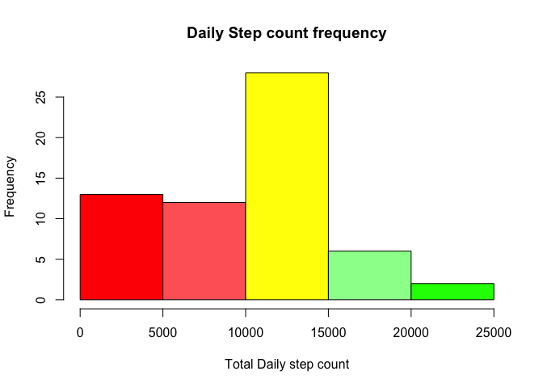

```r
colors = c("red" , "#ff6666", "yellow", "#99ff99" , "#00ff00" )
ag <- aggregate(acti$steps, by=list(acti$date), FUN=sum)[2]
hist( ag$x , col=colors , main= "Daily Step count frequency" , xlab="Total Daily step count")
```

*Clearly, on a normal day, our test subject walk between 10k and 15k steps, with more very inactive days than very active days…*

## What is the average daily activity pattern?

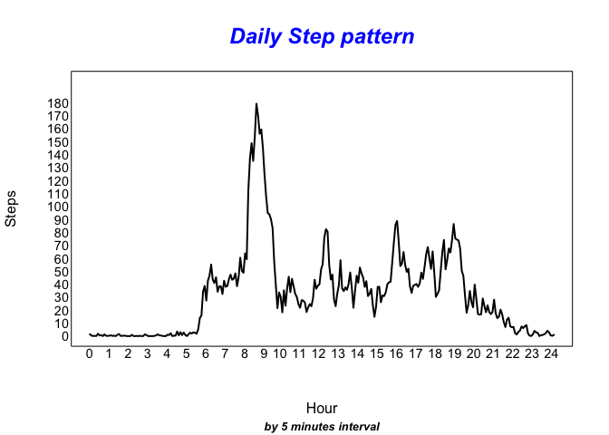

```r
intAg <- aggregate(acti$steps, by=list(acti$interval), FUN=mean)

plot( intAg$x, type="l", ylim=range(intAg$Group.1/12), axes=F, ann=T, xlab="Hour",
   ylab="Steps", cex.lab=1, lwd=2)

box(lwd=1)
title("Daily Step pattern", sub = "by 5 minutes interval",
      cex.main = 1.5,   font.main= 4, col.main= "blue",
      cex.sub = .8,   font.sub = 4, col.sub = "black")

hlabelScale<-c(0:24)*12
hlabelHour <- c(0:24)
text( hlabelScale+3 , -13 , srt=0, adj=1,
          labels=hlabelHour,
          xpd=T, cex=0.9)

vlabelScale<-c(0:18)*10
vlabelHour <- c(0:18)*10
text( -12 , vlabelScale , srt=0, adj=1,
          labels=vlabelHour,
          xpd=T, cex=0.9)
```

*Subject has a very consistant routine, wakes up at 6:00am, likely walk to work between 8:00am and 9:00am with an abolute peak at 8:45am, get up at noon ( presumatly for lunch ;=) ) and leave work usually at 4:00pm with activity until 7:00pm… rarely fall asleep after 10:00pm*

## Inputing missing values

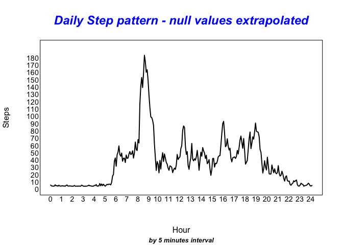

```r
# replacing null value by average
raw[is.na(raw)] <- avg/288
intAg <- aggregate(raw$steps, by=list(raw$interval), FUN=mean)

plot( intAg$x, type="l", ylim=range(intAg$Group.1/12), axes=F, ann=T, xlab="Hour",
   ylab="Steps", cex.lab=1, lwd=2)

box(lwd=1)
title("Daily Step pattern - null values extrapolated", sub = "by 5 minutes interval",
      cex.main = 1.5,   font.main= 4, col.main= "blue",
      cex.sub = .8,   font.sub = 4, col.sub = "black")

hlabelScale<-c(0:24)*12
hlabelHour <- c(0:24)
text( hlabelScale+3 , -13 , srt=0, adj=1,
          labels=hlabelHour,
          xpd=T, cex=0.9)

vlabelScale<-c(0:18)*10
vlabelHour <- c(0:18)*10
text( -12 , vlabelScale , srt=0, adj=1,
          labels=vlabelHour,
          xpd=T, cex=0.9)
```

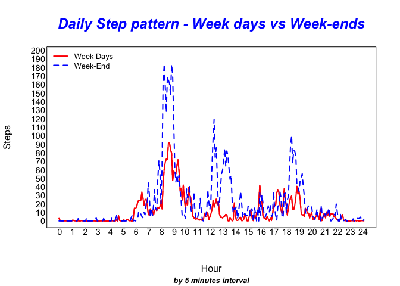

```r
acti$day <- weekdays(as.Date(acti$date),abbreviate=TRUE)

# week days
wd <- acti[acti$day %in% c("Mon", "Tue", "Wen" , "Thu" , "Fri" ), ]
intAg <- aggregate(wd$steps, by=list(wd$interval), FUN=mean)

plot( intAg$x, type="l", ylim=range(intAg$Group.1/6), col="red" , axes=F, ann=T, xlab="Hour",   ylab="Steps", cex.lab=1, lwd=2)
lines( intAg$x , type="l", lty=2, lwd=2,   col="red")

# week ends
we <- acti[acti$day %in% c("Sat", "Sun"), ]
intAg <- aggregate(we$steps, by=list(we$interval), FUN=mean)
lines( intAg$x , type="l", lty=2, lwd=2,   col="blue")

# labels, axis, title, box...
box(lwd=1)
title("Daily Step pattern - Week days vs Week-ends", sub = "by 5 minutes interval",
      cex.main = 1.5,   font.main= 4, col.main= "blue",
      cex.sub = .8,   font.sub = 4, col.sub = "black")

hlabelScale<-c(0:24)*12
hlabelHour <- c(0:24)
text( hlabelScale+4 , -24 , srt=0, adj=1,
          labels=hlabelHour,
          xpd=T, cex=0.9)

vlabelScale<-c(0:20)*20
vlabelHour <- c(0:20)*10
text( -12 , vlabelScale , srt=0, adj=1,
          labels=vlabelHour,
          xpd=T, cex=0.9)

weeks <- c("Week Days","Week-End")
legend("topleft", weeks, cex=0.8, col=c("red","blue"),
   lty=1:3, lwd=2, bty="n");
```

*Our subject is more active on week-ends, with clear peaks of activities around regular meal hours… also appears to sleep an extra hour.*

.. …

*bdolimier - Dec. 20 2015*